# Event study design: How normalisation affects estimation and inference

## Veryfying the code with simulated data

### Using Bacon data

```r
#### https://lost-stats.github.io/Model_Estimation/Research_Design/event_study.html#r
  #### Load and prepare data
####dat = fread("https://raw.githubusercontent.com/LOST-STATS/
#####LOST-STATS.github.io/master/Model_Estimation/Data/Event_Study_DiD/
##### bacon_example.csv")
dat <- fread(FPath("source", "bacon_example.csv"))
  #### Let's create a more user-friendly indicator of which states received treatment
dat[, treat := ifelse(is.na(`_nfd`), 0, 1)]
dat[, time_to_treat := ifelse(treat==1, year - `_nfd`, 0)]
```

`fixest` has `i` function that deals with interaction terms. By default, reference is the first level. Here, -1 is chosen explicitly.

```r
library(fixest)
twfe1 = feols(asmrs ~ i(time_to_treat, treat, ref = -1) |
     #### Our key interaction: time × treatment status
     stfips + year,      #### FEs
     cluster = ~stfips, #### Clustered SEs
     data = dat)
```

```r
ttdum <- makeDummyFromFactor(factor(dat[, time_to_treat]),
  nameprefix = "tt", reference = NULL)
setnames(ttdum, colnames(ttdum), gsub("-", "N", colnames(ttdum)))
ttterms <- paste(colnames(ttdum), collapse = "+")
ttterms2 <- gsub("\\+ttN1\\+", "+", ttterms) # ttN21+...+ttN2+tt0+tt1+...
ttterms3 <- gsub("ttN21\\+", "", ttterms) # ttN20+...+ttN1+tt0+tt1+...
dat[, time := factor(year)]
dat[, id := factor(stfips)]
dt <- data.table(dat, ttdum)
#### 2: no intercept+ttterms2, et=-1 is dropped
#### 3: with intercept+ttterms2, et=-1, id=1 are dropped
#### 4: with intercept+ttterms3, et=-21, id=1 are dropped
twfe2 <- lm(as.formula(paste0("asmrs ~ -1+id+time+", ttterms2)), data = dt)
twfe3 <- lm(as.formula(paste0("asmrs ~ id+time+", ttterms2)), data = dt)
twfe4 <- lm(as.formula(paste0("asmrs ~ id+time+", ttterms3)), data = dt)
tc1 <- twfe1$coeff
names(tc1) <- gsub("ti.*::", "tt", names(tc1))
names(tc1) <- gsub(":treat", "", names(tc1))
names(tc1) <- gsub("-", "N", names(tc1))
for (i in 1:4) {
  if (i > 1) {
    tw <- get(paste0("twfe", i))
    tc <- tw$coeff
  } else tc <- tc1
  tc <- tc[grep("tt", names(tc))]
  tc <- data.table(spec = c("fixest", "no int, -1", "int, -1, id=1", "int, -21, id=1")[i],
    coef = names(tc), val = tc)
  assign(paste0("tcf", i), tc)
}
tcf <- rbindlist(list(tcf1, tcf2, tcf3, tcf4))
tcf[, et := gsub("tt", "", coef)]
tcf[, et := gsub("N", "-", et)]
tcf[, et := as.numeric(et)]
tcf[et == -21, ]
```

```
            spec  coef      val  et
1:        fixest ttN21 -22.8576 -21
2:    no int, -1 ttN21 -22.8576 -21
3: int, -1, id=1 ttN21 -22.8576 -21
```

```r
tcf[et == -1, ]
```

```
             spec coef     val et
1: int, -21, id=1 ttN1 22.8576 -1
```

```r
library(clubSandwich)
ci1 <- data.table(cbind(names(twfe1$coeff), twfe1$coeff, stats::confint(twfe1)))
ci2 <- lapply(list(twfe2, twfe3, twfe4), function(x)
  clubSandwich::conf_int(x, vcov = "CR2", level = 0.95,
  test = "Satterthwaite", cluster = dt[, id], coefs = "All", p_values = T))
ci22 <- lapply(ci2, function(x) data.table(x)[, c("Coef", "beta", "CI_L", "CI_U")])
ci22 <- lapply(ci22, function(x) x[grepl("tt", Coef), ])
ci22 <- lapply(ci22, function(x) x[, et := gsub("tt", "", Coef)])
ci22 <- lapply(ci22, function(x) x[, et := as.numeric(gsub("N", "-", et))])
ci22 <- lapply(1:length(ci22), function(i) ci22[[i]][, estmethod := i+1])
setnames(ci1, c("Coef", "beta", "CI_L", "CI_U"))
ci1[, et := gsub(".*::", "", Coef)]
ci1[, et := as.numeric(gsub(":treat", "", et))]
ci1[, estmethod := 1]
ci22 <- rbindlist(ci22)
ci <- rbindlist(list(ci1, ci22), use.names = T, fill = T)
ci[, estmethod := factor(estmethod, labels = c("fixest", "lm et=-1", "lm et=-1 id=1", "lm et=-21 id=1"))]
```

Parameter estimates: `fixest` and other specifications

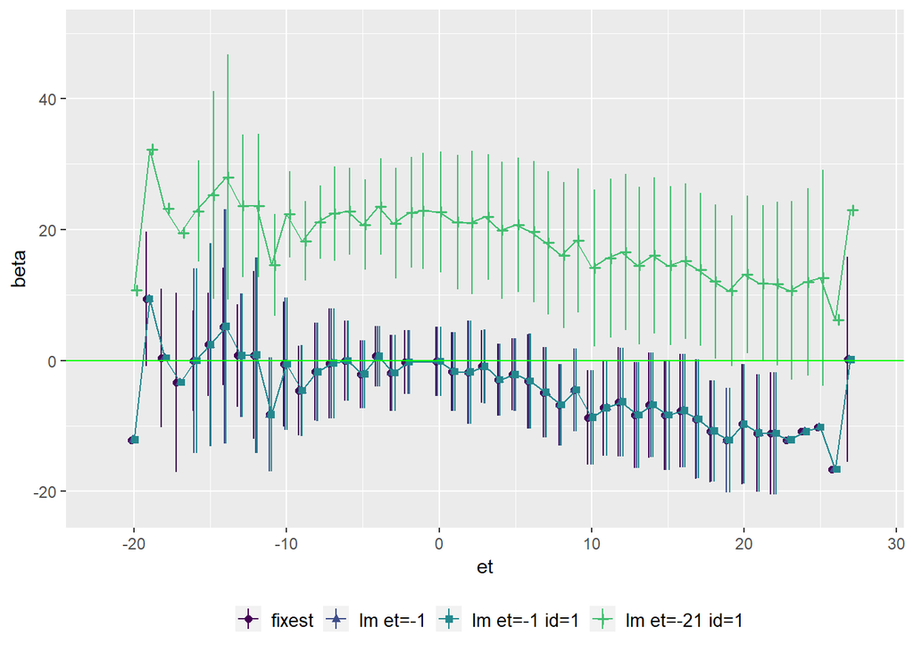

We see that `fixest`, “lm et=-1”, “lm et=-1 id=1” are equivalent, “lm et=-21” gives the estimates with a pararell shift to the above, and with larger SEs.

## Cubic trends

```r
for (ob in c("mr", "dv")) {
  obj <- qread(paste0(pathsave, ob, ".qs"))
  obj <- obj[, time2 := as.numeric(time)]
  obj <- obj[time2 >= 1960 & time2 <= 1988, ]
  #### State dummies
  stdum <- makeDummyFromFactor(factor(obj[, StateName]), nameprefix = "")
    #### Subtract Hawaii to impose \bar{a}_{i} = 0
  stnames <- colnames(stdum)
  setnames(stdum, stnames, gsub(" ", "", stnames))
  stdum[, (stnames) := lapply(.SD, function(x) x-Hawaii), .SDcols = stnames]
  stdum[, Hawaii := NULL]
  stterms <- paste(colnames(stdum), collapse = "+")
  #### Time dummies
  tdum <- makeDummyFromFactor(factor(obj[, time]), nameprefix = "y")
    #### Drop 1961, 1987 for accommodating trend and keep linear independence
  setnames(tdum, colnames(tdum), gsub("19", "", colnames(tdum)))
  tnames <- colnames(tdum)
  tdum[, paste0("y", c(61, 87)) := NULL]
  tterms <- paste(colnames(tdum), collapse = "+")
  etdum <- makeDummyFromFactor(factor(obj[, et]), nameprefix = "et")
  #### Event time dummies
    #### change to easier-to-handle names
  setnames(etdum, grepout("-", colnames(etdum)),
    gsub("-", "N", grepout("-", colnames(etdum))))
  etdumpre = copy(etdum)
  etprepost = copy(etdum)
    #### Subtract t=-L, L=10 period to impose \bar{gamma}_{s<0} = 0
  negtime <- grepout("N", colnames(etdum))
  etdumpre[, (negtime) := lapply(.SD, function(x) x-etN10), .SDcols = negtime]
  etdumpre[, etN10 := NULL]
    #### Subtract t=-1 period to impose
    #### \bar{gamma}_{0} = 0, \gamma_{s\neq 0}=\gamma_{s}-\gamma_{0}
  preposttime <- colnames(etdum)
  etprepost[, (preposttime) := lapply(.SD, function(x) x-etN1),
    .SDcols = preposttime]
  etterms <- paste(colnames(etdum), collapse = "+")
    #### Drop -1 and -10 from et
  etterms1 <- gsub("\\+etN1\\+", "+", etterms)
  etterms2 <- gsub("\\+etN10", "", etterms)
  obj1 <- data.table(obj, stdum, tdum, etdum)
  obj1a <- data.table(obj, stdum, tdum, etprepost)
  obj2 <- data.table(obj, stdum, tdum, etdumpre)
    #### A: TWFE, B: TWFE+trend
  formA. <- paste0("v ~ -1+", stterms, " + ", tterms)
  formB. <- paste0("v ~ -1 + trend +", stterms, " + ", tterms)
  formC. <- paste0("v ~ -1 + trend + I(trend^(2)) + I(trend^(3))+",
    stterms, " + ", tterms)
  formA1 <- paste(formA., "+", etterms1)
  formB1 <- paste(formB., "+", etterms1)
  formC1 <- paste(formC., "+", etterms1)
  formA2 <- paste(formA., "+", etterms2)
  formB2 <- paste(formB., "+", etterms2)
  formC2 <- paste(formC., "+", etterms2)
  obj1[, id := 1:.N]
  obj2[, id := 1:.N]
  rA0 <- lm(as.formula(formA.), data = obj1)
  rB0 <- lm(as.formula(formB.), data = obj1)
  rC0 <- lm(as.formula(formC.), data = obj1)
  rA1 <- lm(as.formula(formA1), data = obj1)
  rB1 <- lm(as.formula(formB1), data = obj1)
  rC1 <- lm(as.formula(formC1), data = obj1)
  rA2 <- lm(as.formula(formA2), data = obj2)
  rB2 <- lm(as.formula(formB2), data = obj2)
  rC2 <- lm(as.formula(formC2), data = obj2)
  #### All coefficients are relative to t=-1 (which is set to zero)
  rA0a <- lm(as.formula(formA.), data = obj1a)
  rB0a <- lm(as.formula(formB.), data = obj1a)
  rC0a <- lm(as.formula(formC.), data = obj1a)
  rA1a <- lm(as.formula(formA1), data = obj1a)
  rB1a <- lm(as.formula(formB1), data = obj1a)
  rC1a <- lm(as.formula(formC1), data = obj1a)
  assign(paste0(ob, "reg"), list(
    "TWFE"=rA0, "TWFE+t"=rB0, "TWFE+t3"=rC0,
    "TWFE+et"=rA1, "TWFE+t+et"=rB1, "TWFE+t3+et"=rC1,
    "TWFEa"=rA0a, "TWFEa+t"=rB0a, "TWFEa+t3"=rC0a,
    "TWFEa+et"=rA1a, "TWFEa+t+et"=rB1a, "TWFEa+t3+et"=rC1a,
    "TWFE+et, pre-period"=rA2, "TWFE+t+et, pre-period"=rB2,
    "TWFE+t3+et, pre-period"=rC2
    ))
  #### CI
  normalizationABC <- c("TWFE", "TWFE trend", "TWFE trend3")
  normalization123 <- c("no et", "-1", "pre-mean=0")
  Ci <- NULL
  for (ch in 1:3) {
    for (i in 0:2) {
      for (j in c("", "a")) {
        if (i==2 & j == "a") next
        rr <- get(paste0("r", LETTERS[ch], i, j))
        id <- as.numeric(names(rr$resid))
        clus <- obj1[id, StateName]
        #clus <- data.table(rr$model)[, StateName]
        rrc <- clx(rr, cluster = clus, returnV = T)
        clxci <- data.table(cbind(Coef = rownames(rrc$ci), rrc$est, rrc$ci))
        clxci[, normalABC := gsub("FE", paste0("FE", j), normalizationABC[ch])]
        clxci[, normal123 := normalization123[i+1]]
        Ci <- rbind(Ci, clxci)
      }
    }
  }
  Ci[, period := gsub("et", "", Coef)]
  Ci <- Ci[grepl("^.?\\d", period), ]
  Ci[, period := gsub("N", "-", period)]
  Ci[, period := as.numeric(period)]
  setcolorder(Ci, c("Coef", "Estimate", "Std. Error", "t value", "Pr(>|t|)",
    "2.5 %", "97.5 %", "period"))
  setnames(Ci, c("Estimate", "2.5 %", "97.5 %"), c("beta", "CI_L", "CI_U"))
  numcols <- c("beta", "CI_L", "CI_U", "period", "Std. Error", "t value", "Pr(>|t|)")
  Ci[, (numcols) := lapply(.SD, as.numeric), .SDcols = numcols]
  strcols <- colnames(Ci)[!(colnames(Ci) %in% numcols)]
  Ci[, (strcols) := lapply(.SD, factor), .SDcols = strcols]
  Ci[grepl("mea", normal123) & period < 0, mean(beta), by = normalABC]
  qsave(Ci, paste0(pathsave, ob, "ci.qs"))
}
```

Trend terms:

```r
library(modelsummary)
Results <- list("Divorce rates"=dvreg, "Marriage rates"=mrreg)
ii <- as.vector(which(unlist(lapply(dvreg,
  function(x) any(grepl("tre", names(coef(x))))))))
ii <- ii[ii > 3]
####res <- c(Results[[1]][ii], Results[[2]][ii])
####ms <- modelsummary(res,
####  ####output = "gt",
####  output = "kableExtra",
####  stars = TRUE,
####  title = "Trend terms in two-way FEs of event study estimates",
####  ####coef_omit = "Sta|time|^et.?[123][1-9]|[23]0",
####  #### Need single quotes, double quotes give an error
####  coef_map = c('trend' = 'Linear trend $t$', 'I(trend^(2))' = 'Squared trend $t^{2}$',
####    'I(trend^(3))' = 'Cubic trend $t^{3}$'),
####  gof_omit = 'IC|Adj|F|RMSE|Log')
#### column labels
###library(gt)
###ms <- tab_spanner(data = ms, label = 'Divorce rates', columns = 2:6)
###ms <- tab_spanner(data = ms, label = 'Marriage rates', columns = 7:11)
res <- list("Divorce rates" = Results[[1]][ii], "Marriage rates" = Results[[2]][ii])
ms <- modelsummary(res,
  ####output = "gt",
  output = "kableExtra",
  stars = TRUE,
  shape = "rbind",
  title = "Trend terms in two-way FEs of event study estimates",
  ####coef_omit = "Sta|time|^et.?[123][1-9]|[23]0",
  #### Need single quotes, double quotes give an error
  coef_map = c('trend' = 'Linear trend $t$', 'I(trend^(2))' = 'Squared trend $t^{2}$',
    'I(trend^(3))' = 'Cubic trend $t^{3}$'),
  gof_omit = 'IC|Adj|F|RMSE|Log')
library(kableExtra)
ms <- kable_styling(ms, bootstrap_options = "striped", full_width = F)
footnote(ms, general = "**TWFE**: two-way fixed effects of years and states; **t**: trend, **et**: even-time dummies; **t3**: linear, squared, and cubic trends; **TWFEa**: TWFE+dropping 61&87; **pre-period**: mean of pre-period = 0.")
```

Trend terms in two-way FEs of event study estimates

|  | TWFE+t+et | TWFE+t3+et | TWFEa+t | TWFEa+t3 | TWFEa+t+et | TWFEa+t3+et | TWFE+t+et, pre-period | TWFE+t3+et, pre-period |
| --- | --- | --- | --- | --- | --- | --- | --- | --- |
| *Divorce rates* |  |  |  |  |  |  |  |  |
| Linear trend $t$ | 0.220*** | 0.619* | 0.177*** | 1.892*** | 0.233*** | 0.625** | 0.346*** | 1.248*** |
|  | (0.007) | (0.253) | (0.004) | (0.157) | (0.004) | (0.224) | (0.008) | (0.174) |
| Squared trend $t^{2}$ |  | -0.121 |  | -0.403*** |  | -0.120 |  | -0.248*** |
|  |  | (0.078) |  | (0.063) |  | (0.073) |  | (0.065) |
| Cubic trend $t^{3}$ |  | 0.004 |  | 0.012*** |  | 0.004 |  | 0.007*** |
|  |  | (0.002) |  | (0.002) |  | (0.002) |  | (0.002) |
| Num.Obs. | 986 | 986 | 986 | 986 | 986 | 986 | 986 | 986 |
| R2 | 0.989 | 0.989 | 0.976 | 0.988 | 0.989 | 0.989 | 0.989 | 0.990 |
| *Marriage rates* |  |  |  |  |  |  |  |  |
| Linear trend $t$ | 0.495*** | 4.220*** | 0.384*** | 7.393*** | 0.585*** | 4.368*** | 0.942*** | 5.872*** |
|  | (0.017) | (0.549) | (0.014) | (0.338) | (0.010) | (0.488) | (0.022) | (0.386) |
| Squared trend $t^{2}$ |  | -0.917*** |  | -1.650*** |  | -0.946*** |  | -1.263*** |
|  |  | (0.169) |  | (0.136) |  | (0.160) |  | (0.144) |
| Cubic trend $t^{3}$ |  | 0.027*** |  | 0.048*** |  | 0.028*** |  | 0.037*** |
|  |  | (0.005) |  | (0.004) |  | (0.005) |  | (0.005) |
| Num.Obs. | 957 | 957 | 957 | 957 | 957 | 957 | 957 | 957 |
| R2 | 0.990 | 0.990 | 0.951 | 0.989 | 0.989 | 0.990 | 0.986 | 0.991 |

+ p < 0.1, * p < 0.05, ** p < 0.01, *** p < 0.001  
Note:  
**TWFE**: two-way fixed effects of years and states; **t**: trend, **et**: even-time dummies; **t3**: linear, squared, and cubic trends; **TWFEa**: TWFE+dropping 61&87; **pre-period**: mean of pre-period = 0.

Impacts on divorce rates

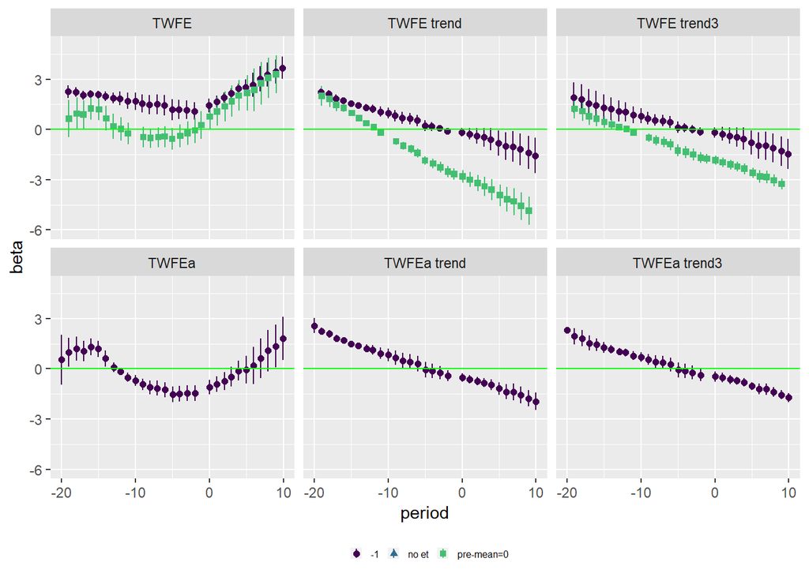

Impacts on marriage rates

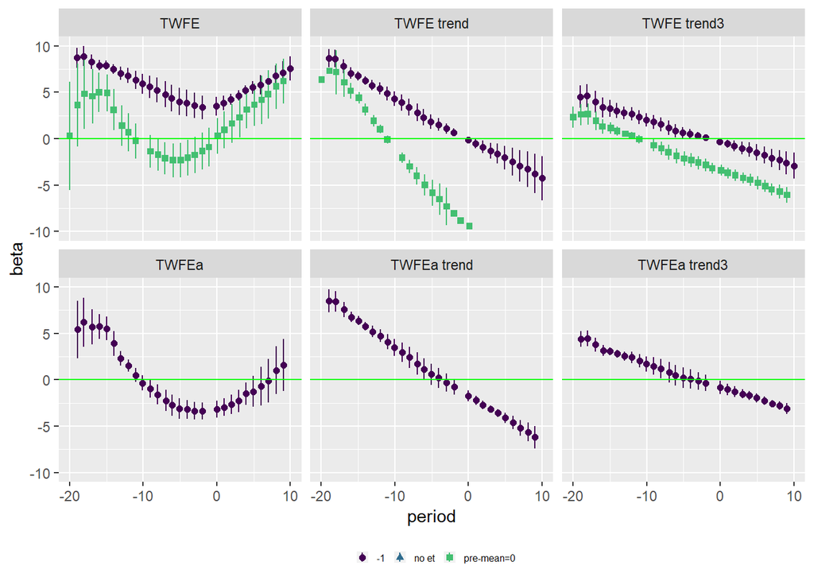

# Final remarks

- Choice of normalization can be consequential. A careful choice is needed.
- For the outcomes showing S shaped growth, such as divorce and marriage rates in the US, simple linear trend may not be the best choice.
- Traditionally, statistics used logistic regressions for S shaped outcomes. But this means we cannot use linear models, or TWFE event study design.
- A more flexible trending modelling with TWFE may be fruitful. Cubic trends did not fit well in the current data.